# NBA_02

Sara Bengoechea Rodriguez

11/5/2020

# Limpieza de datos

Se eliminan las filas duplicadas y con valores nulos, las columnas con variables categóricas (país y equipo) y se ponen todos los nombres de las columnas en minúscula. El resultado sería el siguiente:

|  | player | salary | nba_draft_number | age | g | mp | per | ts | x3p_ar | f_tr | orb | drb | trb | ast | stl | blk | tov | usg | ows | dws | ws | ws_48 | obpm | dbpm | bpm | vorp |
| --- | --- | --- | --- | --- | --- | --- | --- | --- | --- | --- | --- | --- | --- | --- | --- | --- | --- | --- | --- | --- | --- | --- | --- | --- | --- | --- |
| 1 | Zhou Qi | 815615 | 43 | 22 | 16 | 87 | 0.6 | 0.303 | 0.593 | 0.370 | 6.5 | 16.8 | 11.7 | 1.5 | 1.1 | 6.8 | 18.2 | 19.5 | -0.4 | 0.1 | -0.2 | -0.121 | -10.6 | 0.5 | -10.1 | -0.2 |
| 2 | Zaza Pachulia | 3477600 | 42 | 33 | 66 | 937 | 16.8 | 0.608 | 0.004 | 0.337 | 11.0 | 25.0 | 18.5 | 15.4 | 1.9 | 1.3 | 19.3 | 17.2 | 1.7 | 1.4 | 3.1 | 0.160 | -0.6 | 1.3 | 0.8 | 0.7 |
| 3 | Zach Randolph | 12307692 | 19 | 36 | 59 | 1508 | 17.3 | 0.529 | 0.193 | 0.140 | 7.0 | 23.8 | 15.0 | 14.9 | 1.4 | 0.6 | 12.5 | 27.6 | 0.3 | 1.1 | 1.4 | 0.046 | -0.6 | -1.3 | -1.9 | 0.0 |
| 4 | Zach LaVine | 3202217 | 13 | 22 | 24 | 656 | 14.6 | 0.499 | 0.346 | 0.301 | 1.4 | 14.4 | 7.7 | 18.6 | 1.8 | 0.5 | 9.7 | 29.5 | -0.1 | 0.5 | 0.4 | 0.027 | -0.7 | -2.0 | -2.6 | -0.1 |
| 5 | Zach Collins | 3057240 | 10 | 20 | 62 | 979 | 8.2 | 0.487 | 0.387 | 0.146 | 4.9 | 18.3 | 11.7 | 7.3 | 0.8 | 2.5 | 15.6 | 15.5 | -0.4 | 1.2 | 0.8 | 0.038 | -3.7 | 0.9 | -2.9 | -0.2 |
| 6 | Yogi Ferrell | 1312611 | 62 | 24 | 79 | 2238 | 11.5 | 0.543 | 0.489 | 0.141 | 1.3 | 11.3 | 6.1 | 13.3 | 1.4 | 0.3 | 9.1 | 17.0 | 1.6 | 1.6 | 3.1 | 0.067 | -0.4 | -0.5 | -0.9 | 0.6 |

# Summary

Visualizamos un resumen de los estadísticos más relevantes.

Es destacable que el histograma del salario no sigue una distribución normal, por lo que puede ser conflictivo para predecir.

Data summary

| Name | raw_data |
| --- | --- |
| Number of rows | 481 |
| Number of columns | 26 |
| _______________________ |  |
| Column type frequency: |  |
| factor | 1 |
| numeric | 25 |
| ________________________ |  |
| Group variables | None |

**Variable type: factor**

| skim_variable | n_missing | complete_rate | ordered | n_unique | top_counts |
| --- | --- | --- | --- | --- | --- |
| player | 0 | 1 | FALSE | 481 | Aar: 1, Aar: 1, Aar: 1, Abd: 1 |

**Variable type: numeric**

| skim_variable | n_missing | complete_rate | mean | sd | p0 | p25 | p50 | p75 | p100 | hist |
| --- | --- | --- | --- | --- | --- | --- | --- | --- | --- | --- |
| salary | 0 | 1 | 6682859.45 | 7405536.17 | 46080.00 | 1471382.00 | 3290000.00 | 1.00e+07 | 34682550.00 | ▇▂▁▁▁ |
| nba_draft_number | 0 | 1 | 29.29 | 21.10 | 1.00 | 10.00 | 24.00 | 4.70e+01 | 62.00 | ▇▅▃▃▆ |
| age | 0 | 1 | 26.29 | 4.27 | 19.00 | 23.00 | 26.00 | 2.90e+01 | 41.00 | ▇▇▆▂▁ |
| g | 0 | 1 | 50.52 | 24.67 | 1.00 | 30.00 | 59.00 | 7.10e+01 | 79.00 | ▃▂▂▃▇ |
| mp | 0 | 1 | 1163.17 | 808.61 | 1.00 | 391.00 | 1155.00 | 1.83e+03 | 2898.00 | ▇▅▆▅▂ |
| per | 0 | 1 | 13.36 | 8.74 | -41.10 | 9.90 | 13.30 | 1.66e+01 | 134.10 | ▁▇▁▁▁ |
| ts | 0 | 1 | 0.54 | 0.11 | 0.00 | 0.51 | 0.55 | 5.80e-01 | 1.50 | ▁▇▂▁▁ |
| x3p_ar | 0 | 1 | 0.34 | 0.23 | 0.00 | 0.17 | 0.35 | 4.80e-01 | 1.00 | ▇▇▇▂▁ |
| f_tr | 0 | 1 | 0.26 | 0.30 | 0.00 | 0.16 | 0.23 | 3.20e-01 | 5.33 | ▇▁▁▁▁ |
| orb | 0 | 1 | 4.91 | 4.58 | 0.00 | 1.80 | 3.30 | 7.10e+00 | 35.90 | ▇▂▁▁▁ |
| drb | 0 | 1 | 15.03 | 6.80 | 0.00 | 10.30 | 14.00 | 1.88e+01 | 37.60 | ▂▇▅▂▁ |
| trb | 0 | 1 | 9.97 | 4.93 | 0.00 | 6.20 | 8.70 | 1.33e+01 | 26.50 | ▂▇▃▂▁ |
| ast | 0 | 1 | 12.96 | 9.09 | 0.00 | 6.90 | 9.90 | 1.72e+01 | 49.40 | ▇▅▂▁▁ |
| stl | 0 | 1 | 1.54 | 0.99 | 0.00 | 1.00 | 1.50 | 1.90e+00 | 12.50 | ▇▁▁▁▁ |
| blk | 0 | 1 | 1.72 | 1.69 | 0.00 | 0.60 | 1.20 | 2.20e+00 | 13.40 | ▇▂▁▁▁ |
| tov | 0 | 1 | 13.12 | 6.12 | 0.00 | 9.90 | 12.50 | 1.56e+01 | 66.70 | ▇▆▁▁▁ |
| usg | 0 | 1 | 18.94 | 5.81 | 5.70 | 15.00 | 17.90 | 2.22e+01 | 45.10 | ▂▇▃▁▁ |
| ows | 0 | 1 | 1.29 | 1.88 | -2.30 | 0.00 | 0.80 | 2.00e+00 | 11.40 | ▇▇▂▁▁ |
| dws | 0 | 1 | 1.19 | 1.03 | 0.00 | 0.30 | 1.00 | 1.80e+00 | 5.60 | ▇▅▂▁▁ |
| ws | 0 | 1 | 2.48 | 2.67 | -1.20 | 0.40 | 1.90 | 3.60e+00 | 15.00 | ▇▅▁▁▁ |
| ws_48 | 0 | 1 | 0.08 | 0.16 | -1.06 | 0.04 | 0.08 | 1.20e-01 | 2.71 | ▁▇▁▁▁ |
| obpm | 0 | 1 | -1.22 | 5.02 | -36.50 | -2.60 | -1.00 | 4.00e-01 | 68.70 | ▁▇▁▁▁ |
| dbpm | 0 | 1 | -0.48 | 2.39 | -14.30 | -1.60 | -0.40 | 1.00e+00 | 6.80 | ▁▁▂▇▁ |
| bpm | 0 | 1 | -1.70 | 5.64 | -49.20 | -3.50 | -1.20 | 6.00e-01 | 54.40 | ▁▁▇▁▁ |
| vorp | 0 | 1 | 0.60 | 1.25 | -1.30 | -0.10 | 0.10 | 9.00e-01 | 8.60 | ▇▃▁▁▁ |

# División en training y testing set

El dataset se divide en el 70% de las líneas (training set) y el 30% restante (test set).

# Training and testing feature model matrices and response vectors

Creamos las feature model matrices and response vectors. El siguiente output muestra la dimensión de dicha matriz.

```
## [1] 339 506
```

# Regresiones

Realizamos la Regresión Lasso (alfa igual 1) Ridge (alfa igual a 0) y Elástica, para los valores de 0.25 y 0.75 de alfa. Los gráficos que se muestran explican cómo, a medida que aumenta lambda, los coeficientes se acercan más a cero.

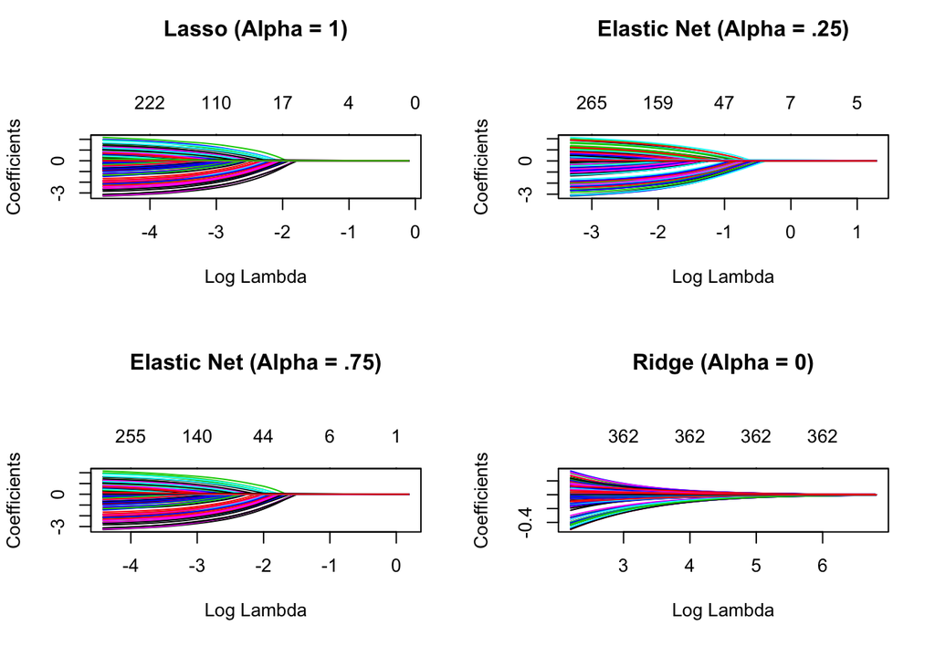

Se realiza un ajuste del modelo mediante cross validation para cada alfa y se extrae MSE y los valores de lambda, que queda representado en la siguient tabla:

| alpha | mse_min | mse_1se | lambda_min | lambda_1se |
| --- | --- | --- | --- | --- |
| 0.0 | 1.633101 | 1.806697 | 9.0455449 | 19.0400050 |
| 0.1 | 1.154589 | 1.277873 | 0.2293375 | 1.4741984 |
| 0.2 | 1.138106 | 1.262469 | 0.1515854 | 1.0207987 |
| 0.3 | 1.126843 | 1.247343 | 0.3548302 | 0.7468835 |
| 0.4 | 1.113682 | 1.219896 | 0.2787943 | 0.5601626 |
| 0.5 | 1.106737 | 1.217415 | 0.2336554 | 0.4694682 |
| 0.6 | 1.103041 | 1.220477 | 0.1947128 | 0.4098519 |
| 0.7 | 1.100185 | 1.211367 | 0.1593110 | 0.3513016 |
| 0.8 | 1.096280 | 1.204595 | 0.1393971 | 0.3073889 |
| 0.9 | 1.092995 | 1.211489 | 0.1239086 | 0.2862448 |

[output cut: 1 more lines]

Su representación gráfica sería como se muestra a continuación.

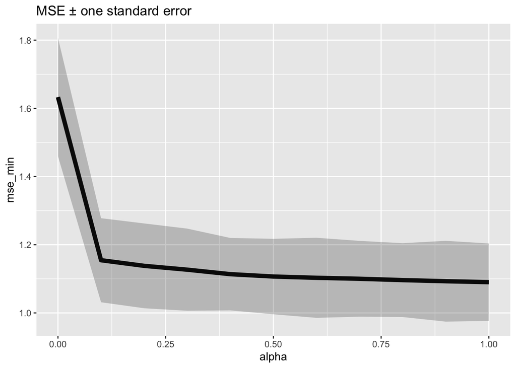

# Mejor modelo y predicción

Si observamos la gráfica anterior y la tabla con los MSE para cada valor de alfa, observamos que el mínimo ocurre cuando alfa es igual a 1, como el modelos lasso. Su mínimo MSE sería el que se muestra a continuación.

```
## [1] 1.072743
```

Con dicha predicción se obtendría el siguiente resultado:

```
## [1] 1.186968
```